# R Notebook

```r
data1=read.csv("C:/Users/KDIVA/OneDrive/Desktop/Intro_to_data_science_project/dataset.csv")
colnames(data1)
```

```
 [1] "X"                                                    "Unnamed..0"
 [3] "GPS.Time"                                             "Device.Time"
 [5] "Longitude"                                            "Latitude"
 [7] "GPS.Speed..Meters.second."                            "Horizontal.Dilution.of.Precision"
 [9] "Altitude"                                             "Bearing"
[11] "G.x."                                                 "G.y."
[13] "G.z."                                                 "G.calibrated."
[15] "X0.100kph.Time.s."                                    "Absolute.Throttle.Position.B..."
[17] "Acceleration.Sensor.Total..g."                        "Acceleration.Sensor.X.axis..g."
[19] "Acceleration.Sensor.Y.axis..g."                       "Acceleration.Sensor.Z.axis..g."
[21] "Accelerator.PedalPosition.D..."                       "Accelerator.PedalPosition.E..."
[23] "Accelerator.PedalPosition.F..."                       "Actual.engine...torque..."
[25] "Air.Fuel.Ratio.Commanded...1."                        "Ambient.air.temp..C."
[27] "Average.trip.speed.whilst.moving.only..km.h."         "Average.trip.speed.whilst.stopped.or.moving..km.h."
[29] "Barometric.pressure..from.vehicle..psi."              "CO..in.g.km..Average..g.km."
```

[output cut: 29 more lines]

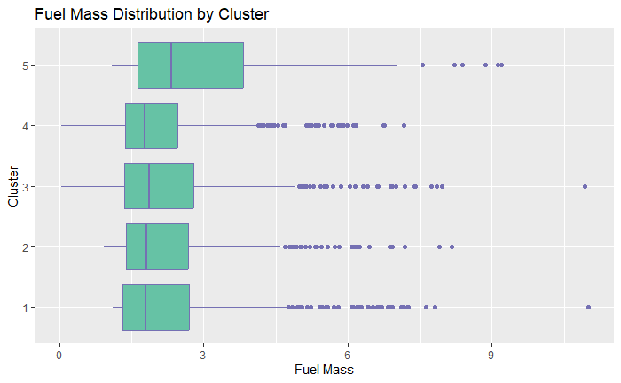

```r
data1$Cluster=as.factor(data1$Cluster)
library(ggplot2)
ggplot(data1, aes(x = Fuel_mass, y = Cluster)) +
  geom_boxplot(fill = "#66c2a5", color = "#7570b3") +
  labs(title = "Fuel Mass Distribution by Cluster", x = "Fuel Mass", y = "Cluster")
```

Clusters- 1,2 and 3 are similar. The analysis would be done such that the driver should avoid cluster 5 as it has the highest fuel mass consumption.

O2 Volts Bank 1 Sensor 1 (V):

This is the voltage output of the first oxygen sensor in Bank 1.

W.R.T Fuel Consumption:

This sensor provides feedback on the air-fuel mixture. Proper mixture leads to better fuel economy. The mixture should not be too lean or too rich.

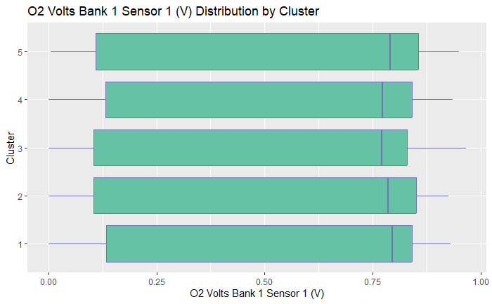

```r
ggplot(data1, aes(x = O2.Volts.Bank.1.sensor.1.V., y = Cluster)) +
  geom_boxplot(fill = "#66c2a5", color = "#7570b3") +
  labs(title = "O2 Volts Bank 1 Sensor 1 (V) Distribution by Cluster", x = "O2 Volts Bank 1 Sensor 1 (V)", y = "Cluster")
```

```r
ci_list <- list()

for (cluster_id in unique(data1$Cluster)) {
  subset_data <- data1[data1$Cluster == cluster_id, ]
  ci <- t.test(subset_data$O2.Volts.Bank.1.sensor.1.V.)
  ci_list[[as.character(cluster_id)]] <- ci$conf.int
}

print(ci_list)
```

```
$`2`
[1] 0.5090679 0.5726126
attr(,"conf.level")
[1] 0.95

$`3`
[1] 0.5037036 0.5734392
attr(,"conf.level")
[1] 0.95

$`4`
[1] 0.5319163 0.5937793
attr(,"conf.level")
[1] 0.95

$`1`
[1] 0.5431888 0.6057935
attr(,"conf.level")
[1] 0.95

$`5`
[1] 0.5267993 0.5946848
attr(,"conf.level")
[1] 0.95
```

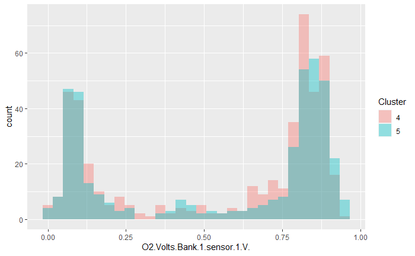

```r
data_o2_sen1 <- data1[data1$Cluster == "4" | data1$Cluster == "5",]
ggplot(data_o2_sen1, aes(x = O2.Volts.Bank.1.sensor.1.V., fill = Cluster)) +
  geom_histogram(position = "identity", alpha = 0.4)
```

O2 Volts Bank 1 Sensor 2 (V):

Similar to the previous parameter, but for the second oxygen sensor in Bank 1.

O2 Volts Bank 1 Sensor 2 (V):

Similar to the first oxygen sensor, this feedback helps maintain proper air-fuel mixture for better fuel economy.

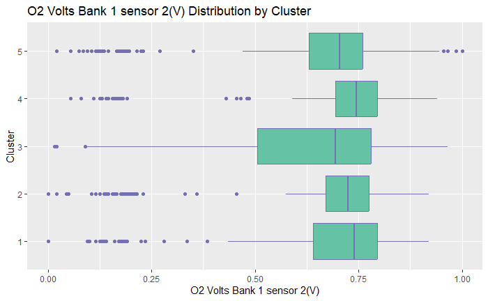

```r
ggplot(data1, aes(x = O2.Volts.Bank.1.sensor.2.V., y = Cluster)) +
  geom_boxplot(fill = "#66c2a5", color = "#7570b3") +
  labs(title = "O2 Volts Bank 1 sensor 2(V) Distribution by Cluster", x = "O2 Volts Bank 1 sensor 2(V)", y = "Cluster")
```

```r
ci_list2 <- list()

for (cluster_id in unique(data1$Cluster)) {
  subset_data <- data1[data1$Cluster == cluster_id, ]
  ci2 <- t.test(subset_data$O2.Volts.Bank.1.sensor.2.V.)
  ci_list2[[as.character(cluster_id)]] <- ci2$conf.int
}

print(ci_list2)
```

```
$`2`
[1] 0.6542866 0.6890329
attr(,"conf.level")
[1] 0.95

$`3`
[1] 0.5927552 0.6402837
attr(,"conf.level")
[1] 0.95

$`4`
[1] 0.6874526 0.7188082
attr(,"conf.level")
[1] 0.95

$`1`
[1] 0.6644153 0.6968015
attr(,"conf.level")
[1] 0.95

$`5`
[1] 0.6415493 0.6760662
attr(,"conf.level")
[1] 0.95
```

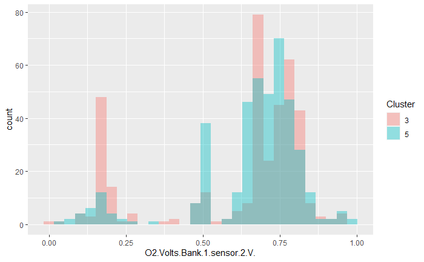

```r
data_o2_sen2 <- data1[data1$Cluster == "3" | data1$Cluster == "5",]
ggplot(data_o2_sen2, aes(x = O2.Volts.Bank.1.sensor.2.V., fill = Cluster)) +
  geom_histogram(position = "identity", alpha = 0.4)
```

Engine kW (At the wheels)(kW):

This represents the power output of the engine that actually reaches the wheels. It helps in understanding how efficiently the engine is converting fuel into usable power for the vehicle’s movement.

Engine kW (At the wheels)(kW) and Horsepower (At the wheels)(hp):

These represent the power output that actually propels the vehicle. Higher power means more energy is being used, which can lead to higher fuel consumption. It’s important to strike a balance between power and efficiency.

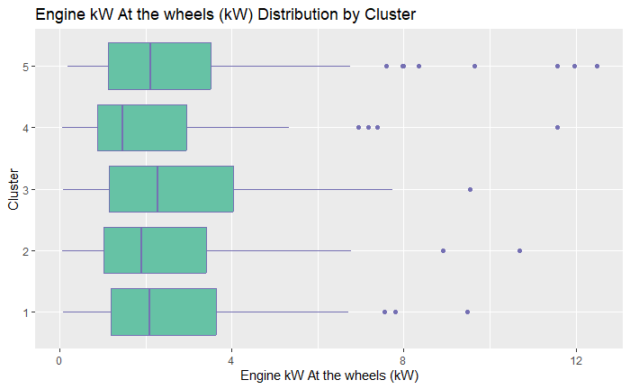

```r
ggplot(data1, aes(x = Engine.kW..At.the.wheels..kW., y = Cluster)) +
  geom_boxplot(fill = "#66c2a5", color = "#7570b3") +
  labs(title = "Engine kW At the wheels (kW) Distribution by Cluster", x = "Engine kW At the wheels (kW)", y = "Cluster")
```

```r
ci_list3 <- list()

for (cluster_id in unique(data1$Cluster)) {
  subset_data <- data1[data1$Cluster == cluster_id, ]
  ci3 <- t.test(subset_data$Engine.kW..At.the.wheels..kW.)
  ci_list2[[as.character(cluster_id)]] <- ci3$conf.int
}

print(ci_list2)
```

```
$`2`
[1] 2.138077 2.573908
attr(,"conf.level")
[1] 0.95

$`3`
[1] 2.468689 3.045146
attr(,"conf.level")
[1] 0.95

$`4`
[1] 1.783225 2.292809
attr(,"conf.level")
[1] 0.95

$`1`
[1] 2.297830 2.801947
attr(,"conf.level")
[1] 0.95

$`5`
[1] 2.415580 2.916532
attr(,"conf.level")
[1] 0.95
```

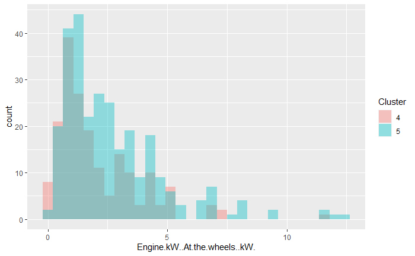

```r
data_enginekw <- data1[data1$Cluster == "5" | data1$Cluster == "4",]
ggplot(data_enginekw, aes(x = Engine.kW..At.the.wheels..kW., fill = Cluster)) +
  geom_histogram(position = "identity", alpha = 0.4)
```

4.Description:

Horsepower (At the wheels)(hp):

Similar to engine kW, this measures the power at the wheels, but it’s in horsepower units. It gives an alternative measurement of the engine’s output.

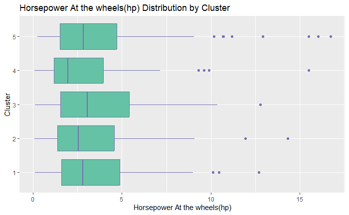

```r
ggplot(data1, aes(x = Horsepower..At.the.wheels..hp., y = Cluster)) +
  geom_boxplot(fill = "#66c2a5", color = "#7570b3") +
  labs(title = "Horsepower At the wheels(hp) Distribution by Cluster", x = "Horsepower At the wheels(hp)", y = "Cluster")
```

```r
ci_list4 <- list()

for (cluster_id in unique(data1$Cluster)) {
  subset_data <- data1[data1$Cluster == cluster_id, ]
  ci4 <- t.test(subset_data$Horsepower..At.the.wheels..hp.)
  ci_list4[[as.character(cluster_id)]] <- ci4$conf.int
}

print(ci_list4)
```

```
$`2`
[1] 2.867208 3.451667
attr(,"conf.level")
[1] 0.95

$`3`
[1] 3.310566 4.083608
attr(,"conf.level")
[1] 0.95

$`4`
[1] 2.391344 3.074708
attr(,"conf.level")
[1] 0.95

$`1`
[1] 3.081441 3.757473
attr(,"conf.level")
[1] 0.95

$`5`
[1] 3.241390 3.915466
attr(,"conf.level")
[1] 0.95
```

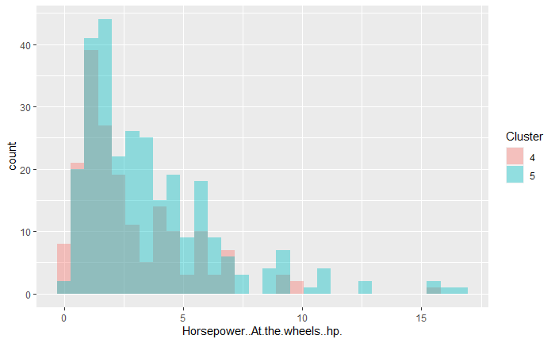

```r
data_hp <- data1[data1$Cluster == "4" | data1$Cluster == "5",]
ggplot(data_hp, aes(x = Horsepower..At.the.wheels..hp., fill = Cluster)) +
  geom_histogram(position = "identity", alpha = 0.4)
```